# Task 3: JackKnife

## Introduction

JackKnife is a re-sampling technique used for removing bias and statistical errors inherently present in the samples. In the presence of an unbiased sample, produces the same estimate as the original sample. It is a non-parametric method, and therefore free from all assumptions which are associated with the parametric method. It is mainly used for to reduce bias and to estimate variance for estimators such as variance and mean. It is used when the sample’s underlying distribution is not discernible, the sample size is small and can also be used just as an alternative to the traditional methods. It uses a Leave-One-Out strategy, for making a large number of sub-samples from an original sample, giving us n samples each with n-1 data points. It doesn’t perform well with non-smooth statistics such as median and non-linear statistics such correlation co-coefficients[1][2]

Although conceptually more complex, it is computationally less intensive than bootstrap, it produces estimates similar to bootstrap, except for the variance estimate, as it does not involve any randomness. To this end its estimates are always the same for a given original sample, unlike bootstrapping which gives different results each time its run.[3]

## Analytical and JackKnife Estimate Comparison for the Seals data

The Original sample’s spread of data points can be seen by these two figures below (Figures 1 and 2). The Seal data set’s box plot and histogram are indicative of a large variance.

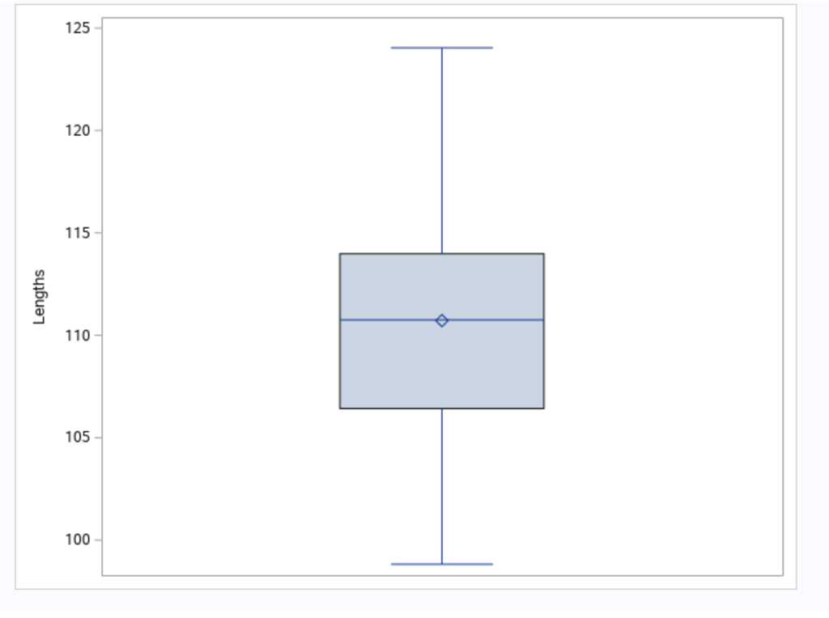

Boxplot for body lengths of the originalseal’s dataset.

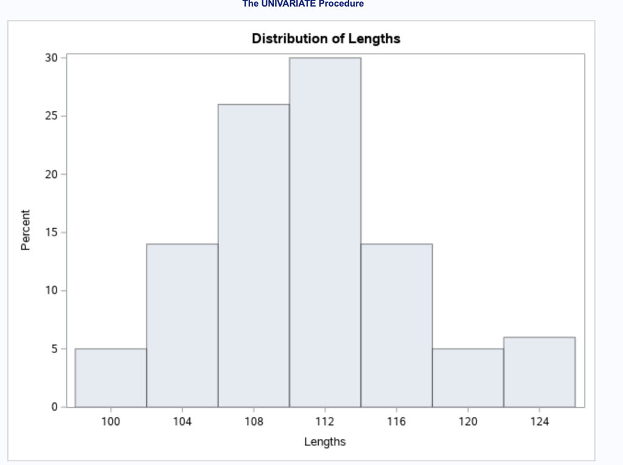

Histogram for body lengths of the original seal’s dataset.

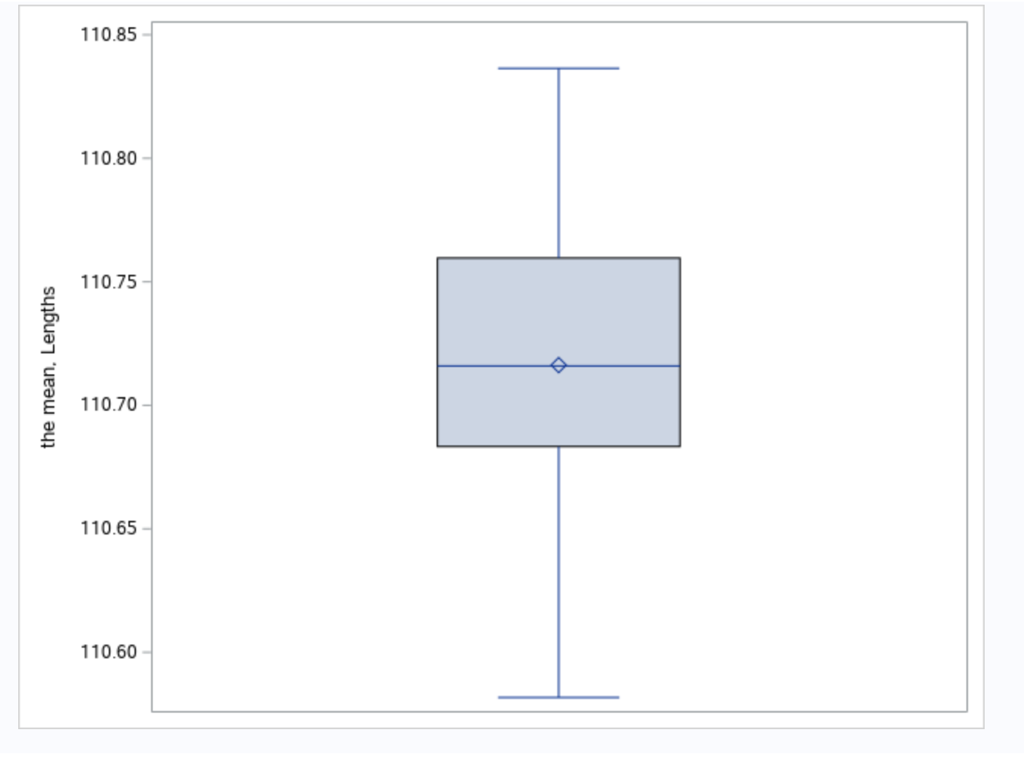

Box plot for JackKnife estimate sample means .

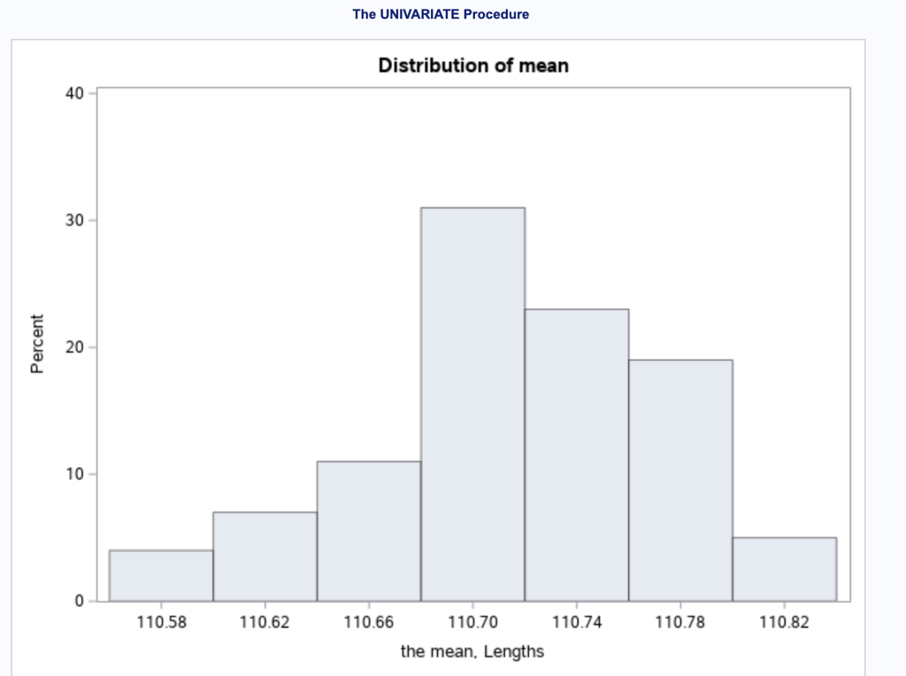

Histogram for JackKnife estimated means for its ‘n’ samples or replicates.

## References

[1] NISBET, R., 2016. Handbook of statistical analysis and data mining applications. 2nd edition, Elsevier academic Press.

[2]Unkown, ‘The JackKnife Approach’, [online] Available at: http://www.hep.fsu.edu/~berg/teach/mcmc08/material/lecture05stat.pdf [Accessed 3 November 2021].

[3]Datasciencecentral.com. 2021. Resampling Methods: Bootstrap vs jackknife. [online] Available at: https://www.datasciencecentral.com/profiles/blogs/resampling-methods-comparison [Accessed 3 November 2021].

## Appendix

### SAS Code for the Task

```
knitr::opts_chunk$set(echo = TRUE)
#/*Importing the seals dataset*/
proc import out=seals
DBMS=CSV replace
file="/home/u59691081/New Folder/seals.csv";
getnames=yes;
datarow=2;
run;
#Analysing the spread of data points for our original data set.

#Using Histogram to visualize the spread.
proc univariate data=seals;
histogram lengths/ ctext=black;
run;

#Using boxplot to visualize the spread.
proc sgplot data=seals;
vbox lengths;
run;

#Calculating the true mean length of the dataset
proc means Data=seals;
var lengths;
output out=truemeans mean=mean;
run;
#mean of the original data set is 110.71628445

#'&size' will now contain the number of rows of the data set
proc sql noprint;
 select count(*) into :size from seals;
 quit;
#calculating the true standard deviation for the dataset
proc means data=seals;
var lengths;
output out=truestd std=standarddeviation;
run;
#Standard deviation of the original sample is 5.5377124684"

#assigning mean from the truemeans to &trueMean
data _null_;
```

[output cut: 54 more lines]

```
run;
#4. Getting the number of sample size to multiply, to form the JackKnife StandardError equation.
a. This will give us the number 99, the sample size for each individual replicate
data have;
do n=1 to &size-2;
end;
output;
run;
#b. Using the equation to calculate the JackKnife Standard Error
data JstdError;
set have;
JStd_Error=sqrt((n-1)*(&diffSum)/n);
drop n;
run;
#Standard Error of the Collection of JackKnife Samples is 0.5537429954
```